# Lecture 15: Statistical Distributions

Data Analysis for Psychology in R 1

Tom Booth

Click for slides

## Today

- Discuss why we do not always need to bootstrap
- Role of statistical distributions in inference
- Major focus on normal distribution

## Learning objectives

- Develop understanding of probability distributions.
- Increase awareness of the role of central limit theorem for hypothesis testing.

## Inference

- We have used bootstraps to get across the idea of a sampling distribution.
- In inference, we want to know what the variance in the sampling distribution is, given some specified value of the unknown population parameter of interest ($H_{0}$).
- From this, we can say something about how probable our sample estimate is given $H_{0}$.
- How….

## Probability distributions

- Sampling distributions are probability distributions.
- We have seen lots of probability distributions so far in dapR.
- A probability distribution maps the values of a random variable to the probability of it occurring.
- We have noted that for:
  - For discrete distributions we maps to a specific value of outcome.
  - For continuous distributions we map to areas under the curve.
- The mapping occurs via a **probability mass (or density) function**

## Binomial

- We have talked a lot about examples that are formally called **Bernoulli experiments/process**
- Properties:
  - There are two outcomes (success and failure)
  - We have a probability of success ($p$)
  - We are interested in the number of successes ($k$) given a fixed number of trials ($n$)
    - Think how heads in a sequence of coin tosses.
    - Or ESP from lab.

## Binomial PMF

$$f(k,n,p) = Pr(X = k) = \binom{n}{k}p^{k}q^{n-k}$$

- $k$ = number of success
- $n$ = total trials,
- $p$ = probability success
- $q$ = $1-p$ or probability of failure

## An example

- Experiment:
  - Guess the hand a coin is in.
  - 5 trials (n=5)
  - $p(correct) = 0.5$
  - Thus $q = 1 - 0.5 = 0.5$
- We could get 0-5 of these trials correct.
  - So we have 6 possible values of our outcome to calculate the probability for.
  - (see additional slides for working)

## Binomial probability distribution

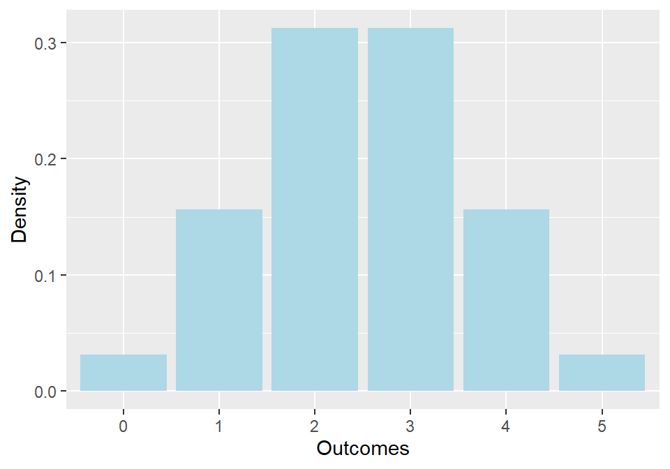

## Cumulative probability

- Another way we can think about representing probability of outcomes is cumulatively.
- Cumulative probability distributions provide a way to easily see the total probability of all values before r after a given point.

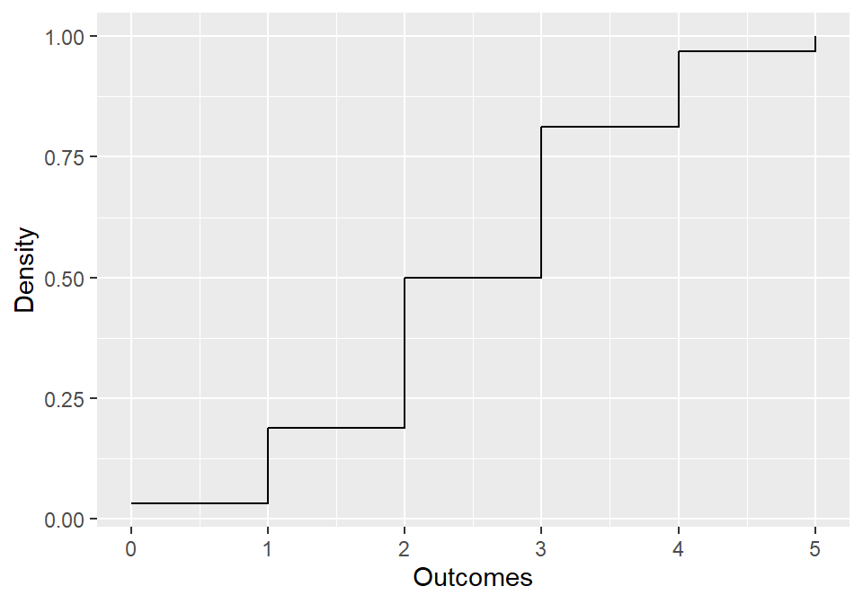

- The cumulative probability function in the case of binomial simply sums the probabilities of the individual outcomes.

## Comparing PMF & CDF

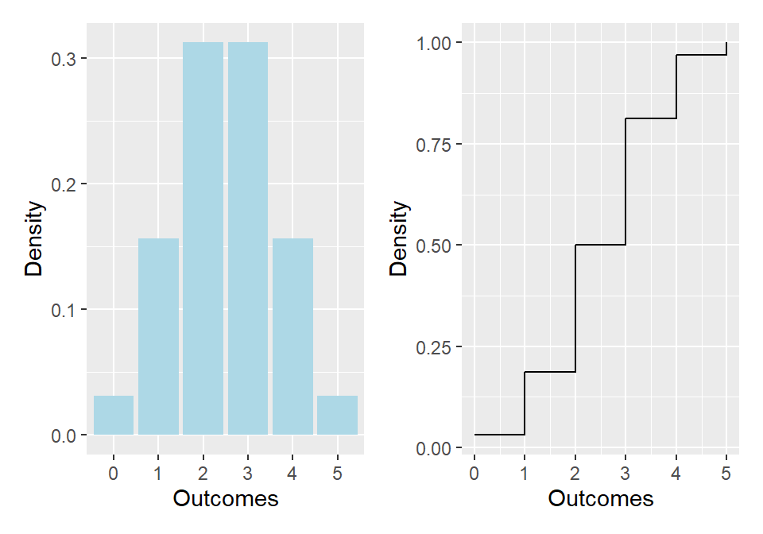

## Normal distribution

- This term normal distribution has come up a lot.
- A normal distribution is a continuous distribution
- It is uni-modal (one peak) and symmetrical
- Also referred to as the Gaussian distribution

## Normal: PDF

$$f(x|\mu, \sigma) = \frac{1}{\sigma\sqrt{2\pi}}e^{-\frac{x-\mu^2}{2\sigma^2}}$$

- A little bit scary!
- But the basic points are:
  - It is a function of data ($x$)
  - And two parameters $\mu$ and $\sigma$ (mean and SD)

## Normal family

- There is not one single normal distribution.
- We have a family of different distributions defined by the mean ($\mu$) and standard deviation ($\sigma$)

## Different normals

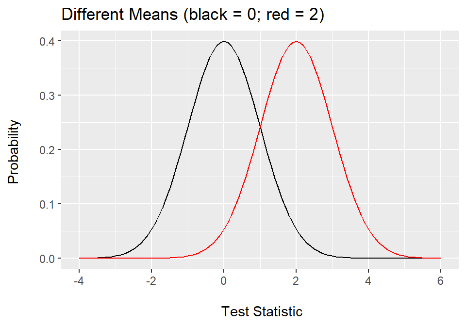

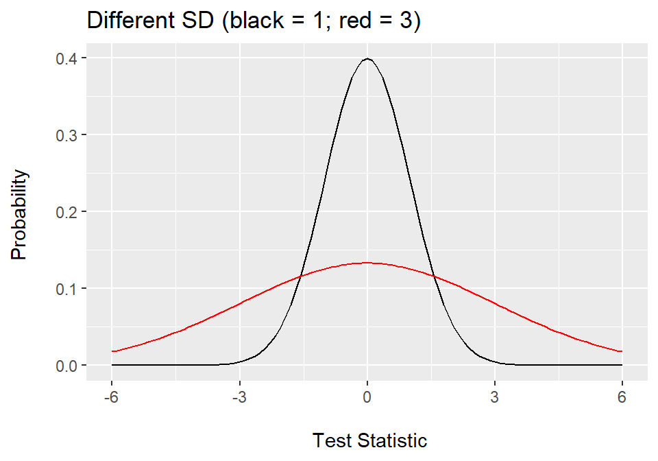

## Properties of normal

- Nice properties of any normal distribution:
  - $\approx\frac{1}{2}$ of area falls under $\frac{2}{3}$ of a SD on either side of mean
  - $\approx\frac{2}{3}$ of area falls under 1 SD on either side of mean
  - $\approx$ 95% of area falls under 2 SD on either side of mean
- **Exactly** 95% falls under +/- 1.96 SD
  - $\approx 99.75%$ of area falls under 3 SD on either side of mean.

## Z-scores

$$Z = \frac{x - \mu}{\sigma}$$

- It is quite typical to present a normal distribution in terms of z-scores.
- z-scores standardize values of x.
  - The numerator: converts x to deviations from the mean.
  - The denominator: scales these values based on the observed spread in the data (SD)

## Standard normal

- The distribution of z-scores is call the standard normal distribution.
- It has:
  - Mean = 0
  - SD = 1

## Central limit theorem

- We have briefly noted CLT before. To refresh;
- The Central Limit Theorem states that the sampling distribution of the sample means from any underlying distribution with a defined mean and variance, approaches a normal distribution as the sample size gets larger.
- The resultant sampling distribution has:
  - $\bar{x} = \mu$
  - $\sigma_{\bar{x}}^{2} = \frac{\sigma^2}{N}$
  - $\sigma_{\bar{x}} = \frac{\sigma}{\sqrt{N}}$

## Uniform distribution

- Continuous probability distribution.
- There is an equal probability for all values within a given range.
- Parameters:
  - $a(min)$ and $b(max)$

$$Mean = \frac{1}{2}(a+b)$$

- And

$$Variance = \frac{1}{12}(b-a)^2$$

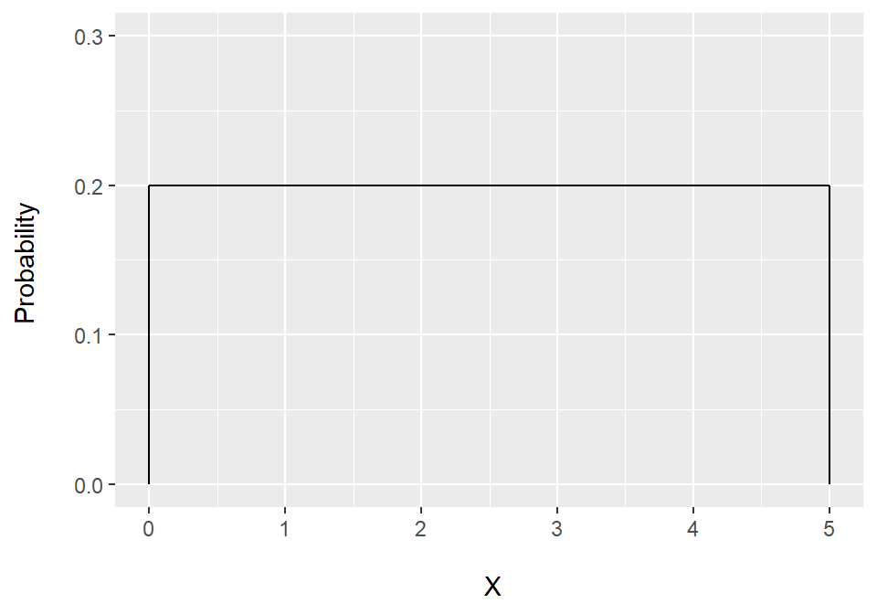

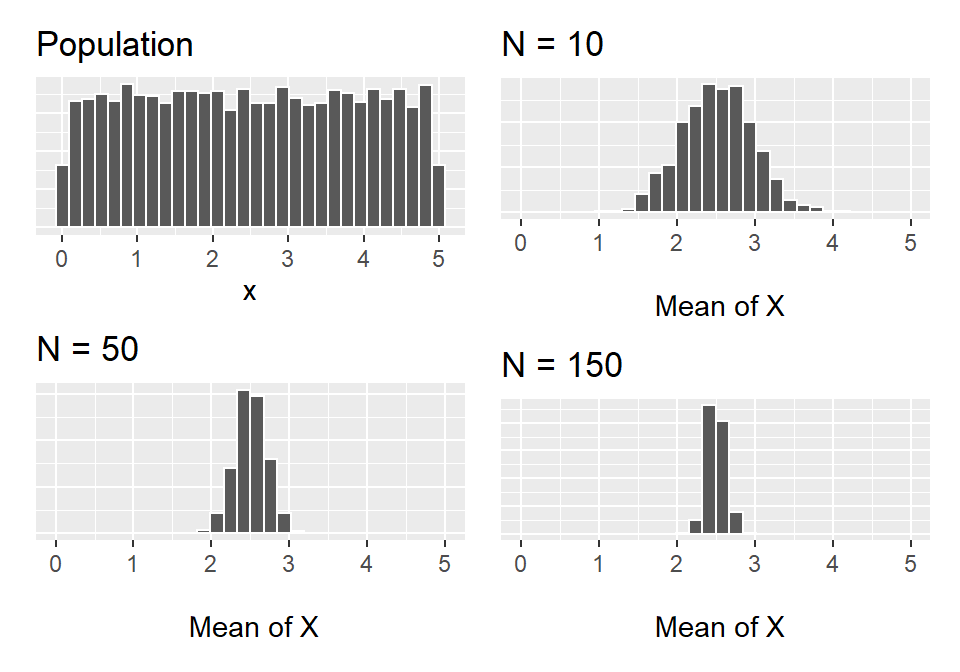

## Chi-square distribution

- Continuous probability distribution
- Non-symmetric
- Parameters = degrees of freedom

$$Mean = df$$

- and

$$Variance = 2*df$$

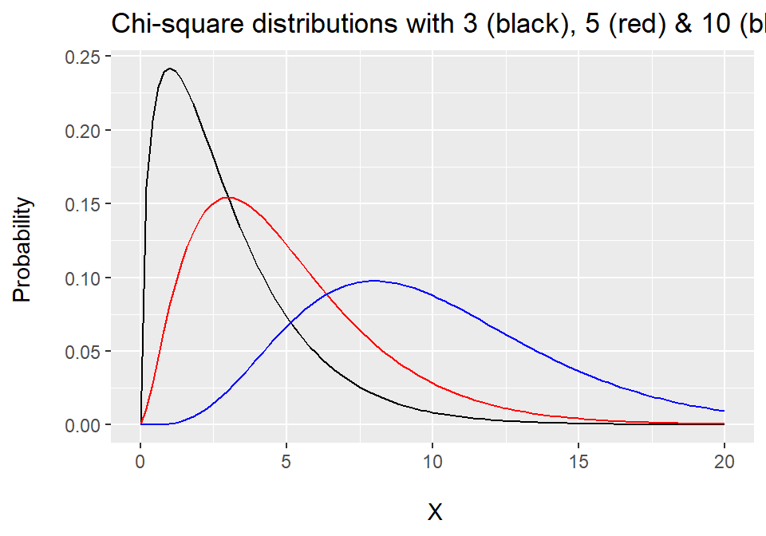

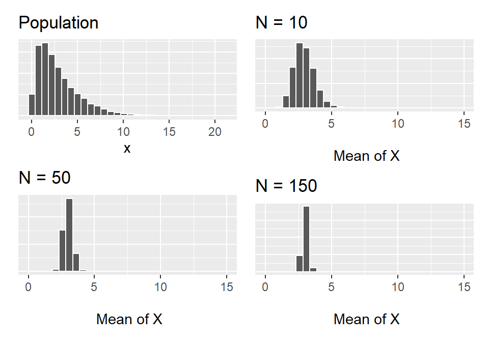

## t-distribution

- Continuous probability distribution.
- Symmetric and uni-modal (similar to the normal distribution).
  - “Heavier tails” = greater chance of observing a value further from the mean
- Parameters:
  - $\nu = n-1$

$$Mean = 0, \nu>1$$

- and

$$Variance = \frac{\nu}{\nu - 2}, \nu > 2$$

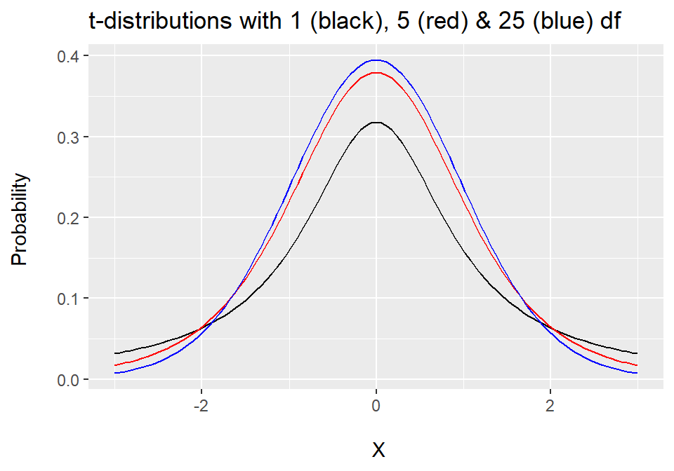

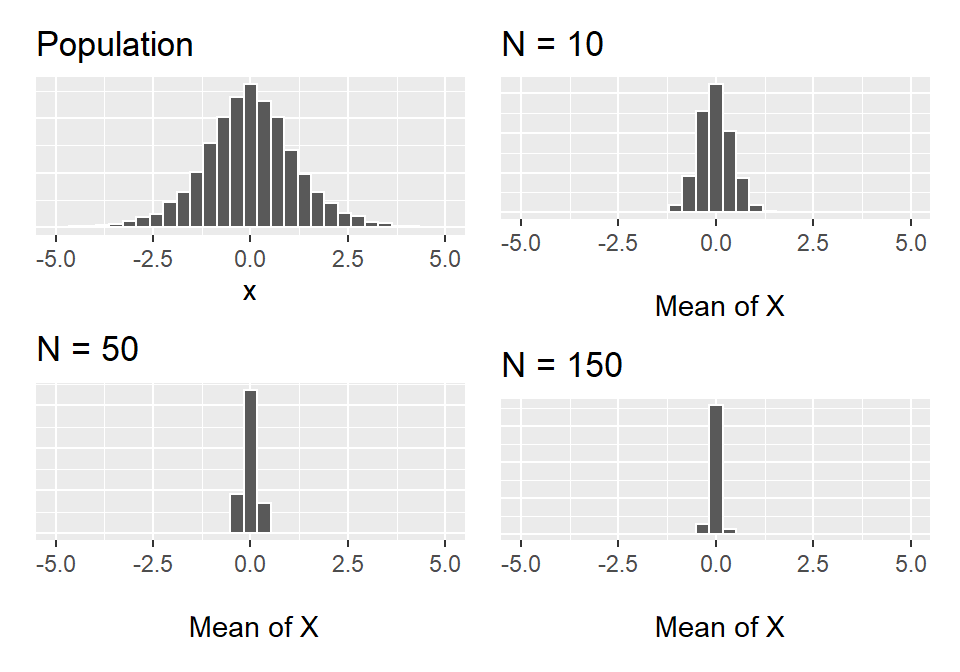

## Sampling distributions

- $\chi^2$ distribution, *t*-distribution and binomial distribution are all commonly used for statistical inference.
- What the CLT demonstrations above show, is that we can often use the normal distribution as an approximation

## Standard error

- One of the big points we have emphasized is sampling variability is characterized by the SD of the sampling distribution.
- But how do we obtain this from a single sample?
- We have already seen the answer thanks to CLT.
- The resultant sampling distribution has:
  - $\bar{x} = \mu$
  - $\sigma_{\bar{x}}^{2} = \frac{\sigma^2}{N}$
  - $\sigma_{\bar{x}} = \frac{\sigma}{\sqrt{N}}$ = standard error

## So why tell us about bootstraps?

- Intuitive understanding.
- Sometimes statistical tools “break”
  - We do not know the sampling distribution for all statistics
  - Sometimes statistical model assumptions are not met.
- If either happen, bootstraps can be a solution.

## Summary

- We can make inferences (NHST system) using statistical distributions.
- Different statistics have different sampling distributions.
- In many cases, the normal is a good approximation due to CLT.

## Tasks for this week…

1. Finish tasks from last week.
2. Quiz 15: Hypothesis Testing
   - Today at 17:00.
   - Close Monday 3rd at 17:00
3. **Lab Test 2**

## Binomial Worked Example

- Experiment:
  - Guess the hand a coin is in.
  - 5 trials (n=5)
  - $p(correct) = 0.5$
  - Thus $q = 1 - 0.5 = 0.5$

## Possible outcomes

- We have 5 trials.
- So our possible outcomes are:

$$X = [0,1,2,3,4,5]$$

## Calculation for X = 3

$$Pr(X = 3) = \binom{n}{k}p^{k}q^{n-k}$$

## Step 1

$$\binom{5}{3}$$

- Is read as 5 choose 3.
- It is the number of possible ways we could get 3 successes
  - That is, we might get trials 1, 2, and 3 correct.
  - Or trials 2, 3, and 5 etc.
- We work out this total number using factorials

## Step 1: Factorials

$$\binom{n}{k} = \frac{n!}{k!(n-k)!}$$

- Where $n!$ for $n=5$ is

$$n! = 5*4*3*2*1 = 120$$

## Step 1: Our calculation

$$\binom{5}{3} = \frac{5!}{3!(5-3)!} = \frac{5!}{3!2!} = \frac{120}{6*2} = 10$$

- There are 10 ways to get three trials correct.

## Step 1: Brute Force

|  | T1 | T2 | T3 | T4 | T5 |
| --- | --- | --- | --- | --- | --- |
| 1 | Y | Y | Y | N | N |
| 2 | Y | Y | N | Y | N |
| 3 | Y | Y | N | N | Y |
| 4 | Y | N | Y | Y | N |
| 5 | Y | N | Y | N | Y |
| 6 | Y | N | N | Y | Y |
| 7 | N | Y | Y | Y | N |
| 8 | N | Y | Y | N | Y |
| 9 | N | Y | N | Y | Y |
| 10 | N | N | Y | Y | Y |

## step 1

$$Pr(X = 3) = 10*p^{k}q^{n-k}$$

- Insert the 10.

## Step 2

$$p^{k}q^{n-k}$$

- We need to add in our probabilities of success, trial number and number of successes.

$$p^{k}q^{n-k} = 0.5^3(1-0.5)^{5-3} = 0.5^30.5^2$$

- Calculate the powers….

$$0.5^3 = 0.5*0.5*0.5 = 0.125$$

And the second…

$$0.5^2 = 0.5*0.5 = 0.25$$

$$p^{k}q^{n-k} = 0.5^30.5^2 = 0.125*0.25 = 0.03125$$

- Insert the values and complete.

## Finish it off

$$Pr(X = 3) = 10*0.03125 = 0.3125$$

- So the probability of three successes in this experiment is 0.3125.
- You can follow these steps for all the other possible outcome values, and confirm the values in the plot from lecture.